# A/B Testing For Fast Food Marketing Campaign

Stephen Situ

2022-11-26

This is a project on A/B Testing for a Fast Food Marketing Campaign. 3 Promotions were offered to different stores with varying MarketID, MarketSize, LocationID, and AgeOfStore. Sales figures were collected over 4 weeks. We first calculated the percentage increase/decrease between each weekly period. Then we defined our KPI as the average of this weekly increase/decrease. We find that Promotion 1 was the most effective in increasing sales and used an ANOVA test with alpha = 0.05 to show that there was no significant statistical evidence to suggest that the means/variance of the 3 groups were different.

Original DataSet: https://www.kaggle.com/datasets/chebotinaa/fast-food-marketing-campaign-ab-test

# Install Packages

```r
install.packages('tidyverse', repos = "http://cran.us.r-project.org")
library(tidyverse)
```

```r
install.packages('ggplot2', repos = "http://cran.us.r-project.org")
library(ggplot2)
```

# Read CSV

```r
ff_df <- read.csv('WA_Marketing-Campaign.csv')
```

# Structure

```r
summary(ff_df)
```

```
##     MarketID       MarketSize          LocationID      AgeOfStore
##  Min.   : 1.000   Length:548         Min.   :  1.0   Min.   : 1.000
##  1st Qu.: 3.000   Class :character   1st Qu.:216.0   1st Qu.: 4.000
##  Median : 6.000   Mode  :character   Median :504.0   Median : 7.000
##  Mean   : 5.715                      Mean   :479.7   Mean   : 8.504
##  3rd Qu.: 8.000                      3rd Qu.:708.0   3rd Qu.:12.000
##  Max.   :10.000                      Max.   :920.0   Max.   :28.000
##    Promotion          week      SalesInThousands
##  Min.   :1.000   Min.   :1.00   Min.   :17.34
##  1st Qu.:1.000   1st Qu.:1.75   1st Qu.:42.55
##  Median :2.000   Median :2.50   Median :50.20
##  Mean   :2.029   Mean   :2.50   Mean   :53.47
##  3rd Qu.:3.000   3rd Qu.:3.25   3rd Qu.:60.48
##  Max.   :3.000   Max.   :4.00   Max.   :99.65
```

```r
str(ff_df)
```

```
## 'data.frame':    548 obs. of  7 variables:
##  $ MarketID        : int  1 1 1 1 1 1 1 1 1 1 ...
##  $ MarketSize      : chr  "Medium" "Medium" "Medium" "Medium" ...
##  $ LocationID      : int  1 1 1 1 2 2 2 2 3 3 ...
##  $ AgeOfStore      : int  4 4 4 4 5 5 5 5 12 12 ...
##  $ Promotion       : int  3 3 3 3 2 2 2 2 1 1 ...
##  $ week            : int  1 2 3 4 1 2 3 4 1 2 ...
##  $ SalesInThousands: num  33.7 35.7 29 39.2 27.8 ...
```

# We Convert Promotion, Market Size, and Market ID to factors

```r
ff_df_true = ff_df
ff_df_true$Promotions = as.factor(ff_df_true$Promotion)
ff_df_true$MarketSizes =  as.factor(ff_df_true$MarketSize)
ff_df_true$MarketIDs =  as.factor(ff_df_true$MarketID)
ff_df_true1 = ff_df_true %>% select(-1,-2,-5)
ff_df_true1
```

```
##     LocationID AgeOfStore week SalesInThousands Promotions MarketSizes
## 1            1          4    1            33.73          3      Medium
## 2            1          4    2            35.67          3      Medium
## 3            1          4    3            29.03          3      Medium
## 4            1          4    4            39.25          3      Medium
## 5            2          5    1            27.81          2      Medium
## 6            2          5    2            34.67          2      Medium
## 7            2          5    3            27.98          2      Medium
## 8            2          5    4            27.72          2      Medium
## 9            3         12    1            44.54          1      Medium
## 10           3         12    2            37.94          1      Medium
## 11           3         12    3            45.49          1      Medium
## 12           3         12    4            34.75          1      Medium
## 13           4          1    1            39.28          2      Medium
## 14           4          1    2            39.80          2      Medium
```

[output cut: 1083 more lines]

# We pivot week column up and create new columns filled with sales value

```r
ff_df_1 <- ff_df_true1 %>%  pivot_wider(id_cols = c('MarketIDs','MarketSizes','LocationID','AgeOfStore','Promotions') , names_from = week , values_from = SalesInThousands)
ff_df_2 <- ff_df_1  %>% rename("Week_1" = "1", "Week_2" = "2", "Week_3" = "3", "Week_4" = "4")
ff_df_2
```

```
## # A tibble: 137 × 9
##    MarketIDs MarketSizes LocationID AgeOfS…¹ Promo…² Week_1 Week_2 Week_3 Week_4
##    <fct>     <fct>            <int>    <int> <fct>    <dbl>  <dbl>  <dbl>  <dbl>
##  1 1         Medium               1        4 3         33.7   35.7   29.0   39.2
##  2 1         Medium               2        5 2         27.8   34.7   28.0   27.7
##  3 1         Medium               3       12 1         44.5   37.9   45.5   34.8
##  4 1         Medium               4        1 2         39.3   39.8   24.8   31.0
##  5 1         Medium               5       10 2         30.4   24.8   37.5   23.4
##  6 1         Medium               6       10 3         32.9   22.2   43.0   26.7
##  7 1         Medium               7       15 1         42.9   42.2   51.7   36.2
##  8 1         Medium               8       10 2         30.1   28.6   25.4   27.3
##  9 1         Medium               9        6 1         37.4   38.6   40.9   41.1
## 10 1         Medium              10        5 2         34.3   29.3   23.9   35.2
## # … with 127 more rows, and abbreviated variable names ¹AgeOfStore, ²Promotions
```

# We Calculate the increase in sales percentage From week to week and then average over the 3 week period to get our KPI

# Key Performance Indicator = Average Increase in Sales Percentage / week

```r
ff_df_3 <- mutate(ff_df_2,
                  week1_2 = ((Week_2 - Week_1)/Week_1)*100,
                  week2_3 = ((Week_3 - Week_2)/Week_2)*100,
                  week3_4 = ((Week_4 - Week_3)/Week_3)*100)

ff_df_4 <-  mutate(ff_df_3, KPI = (week1_2 + week2_3 +  week3_4 )/3)
ff_df_4 %>% select(Promotions,KPI)
```

```
## # A tibble: 137 × 2
##    Promotions   KPI
##    <fct>      <dbl>
##  1 3           7.45
##  2 2           1.48
##  3 1          -6.18
##  4 2          -3.79
##  5 2          -1.66
##  6 3           7.76
##  7 1          -3.05
##  8 2          -2.93
##  9 1           3.22
## 10 2           4.70
## # … with 127 more rows
```

# We Create a boxplot of this KPI by promotion

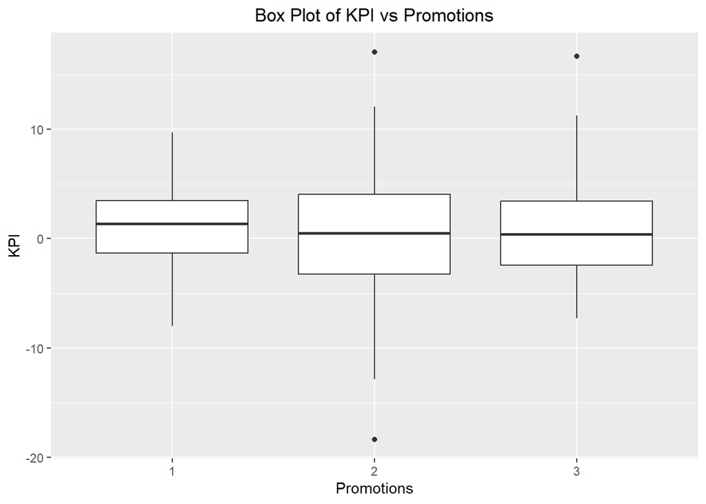

```r
ggplot(data=ff_df_4) +  geom_boxplot(mapping=aes(x=Promotions, y=KPI)) +  ggtitle("Box Plot of KPI vs Promotions") + theme(plot.title = element_text(hjust = 0.5))
```

# We notice 3 outlier points and filter them out

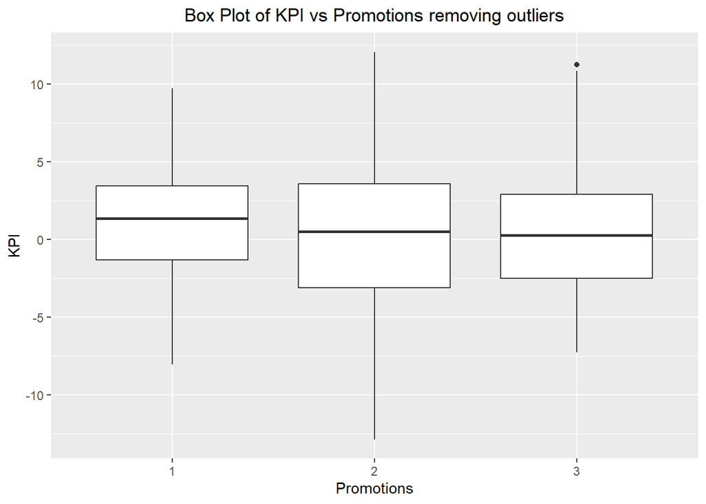

```r
ff_df_5 <- ff_df_4 %>% filter(KPI <= 15 & KPI>-15)
ggplot(data=ff_df_5) +  geom_boxplot(mapping=aes(x=Promotions, y=KPI)) + ggtitle("Box Plot of KPI vs Promotions removing outliers") + theme(plot.title = element_text(hjust = 0.5))
```

# Group By Promotion

```r
ff_df_6 <- ff_df_5 %>% group_by(Promotions) %>% summarise( KPIs = mean(KPI))
ff_df_6
```

```
## # A tibble: 3 × 2
##   Promotions  KPIs
##   <fct>      <dbl>
## 1 1          1.23
## 2 2          0.478
## 3 3          0.975
```

# We find that Promotion 1 had a 1.23% increase in sales, Promotion 2 had a 0.47% increase in sales, and Promotion 3 had a 0.97% increase in sales across

# all categories (all increases are per week). Therefore, we recommend to use Promotion 1 for the greatest increase in sales.

# Now we conduct an ANOVA test for multi-group variance

# Null Hypothesis = There is no difference in the mean between groups of of a population

# Alternative Hypothesis = At least 2 group means differ from each other in the population

# We conduct ANOVA test

```r
promotion_aov <- aov(KPI ~ Promotions, data=ff_df_5)
summary(promotion_aov)
```

```
##              Df Sum Sq Mean Sq F value Pr(>F)
## Promotions    2     13   6.504   0.309  0.735
## Residuals   131   2756  21.034
```

# We obtain P value of 0.735 which is greater than 0.05, so we fail to reject null hypothesis

# There is no significant evidence to suggest that the means/variance of the 3 groups are different